# MH et al. (2021) Results verification

Sau-Chin Chen

2022/3/2

We downloaded the summary data from the authors’ [OSF](https://osf.io/emgya). The did not provide the meta data about the variables. We converted the category variables to factors.

# Data summary

### Metadata

#### Description

**Dataset name**: orig_results

The dataset has N=288 rows and 13 columns. 192 rows have no missing values on any column.

**Metadata for search engines**

- **Date published**: 2022-07-05

| x |
| --- |
| Subject |
| List |
| FirstorSecond |
| Accuracy |
| SentenceBlankPictureGrayACC |
| SentenceBlankPictureColorACC |
| SentenceColorPictureColorACC |
| SentenceColorPictureGrayscaleACC |
| SentenceBlankPictureGrayRT |
| SentenceBlankPictureColorRT |
| SentenceColorPictureColorRT |
| SentenceColorPictureGrayRT |
| Experiment |

### Subject

#### Distribution

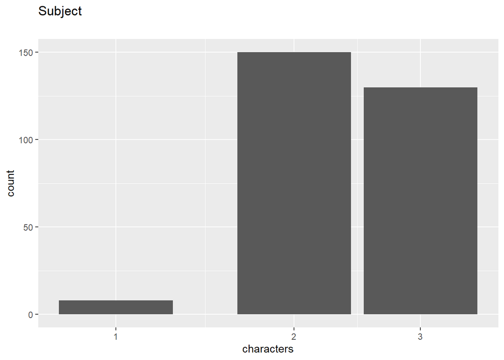

Distribution of values for Subject

0 missing values.

#### Summary statistics

| name | data_type | n_missing | complete_rate | n_unique | empty | min | max | whitespace | label |
| --- | --- | --- | --- | --- | --- | --- | --- | --- | --- |
| Subject | character | 0 | 1 | 225 | 0 | 1 | 3 | 0 | NA |

### List

#### Distribution

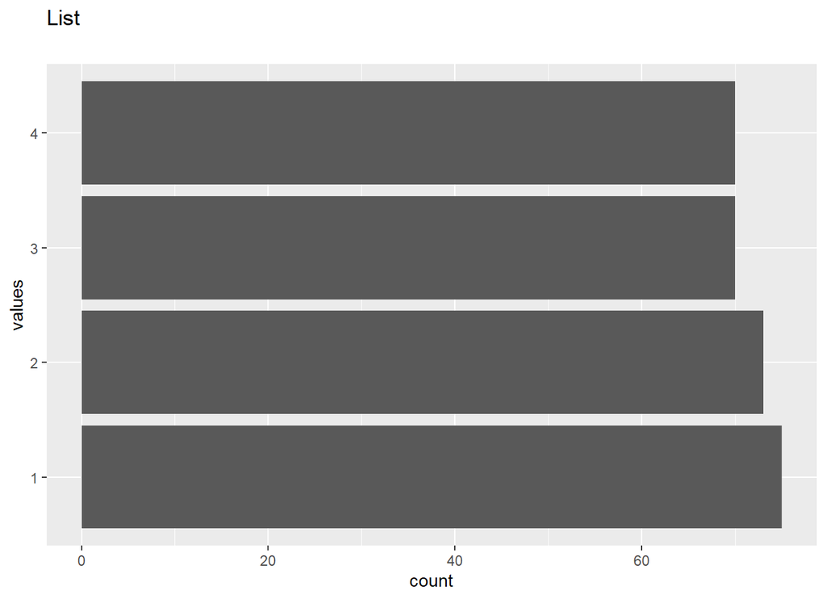

Distribution of values for List

0 missing values.

#### Summary statistics

| name | data_type | ordered | value_labels | n_missing | complete_rate | n_unique | top_counts | label |
| --- | --- | --- | --- | --- | --- | --- | --- | --- |
| List | factor | FALSE | 1. 1, 2. 2, 3. 3, 4. 4 | 0 | 1 | 4 | 1: 75, 2: 73, 3: 70, 4: 70 | NA |

### FirstorSecond

#### Distribution

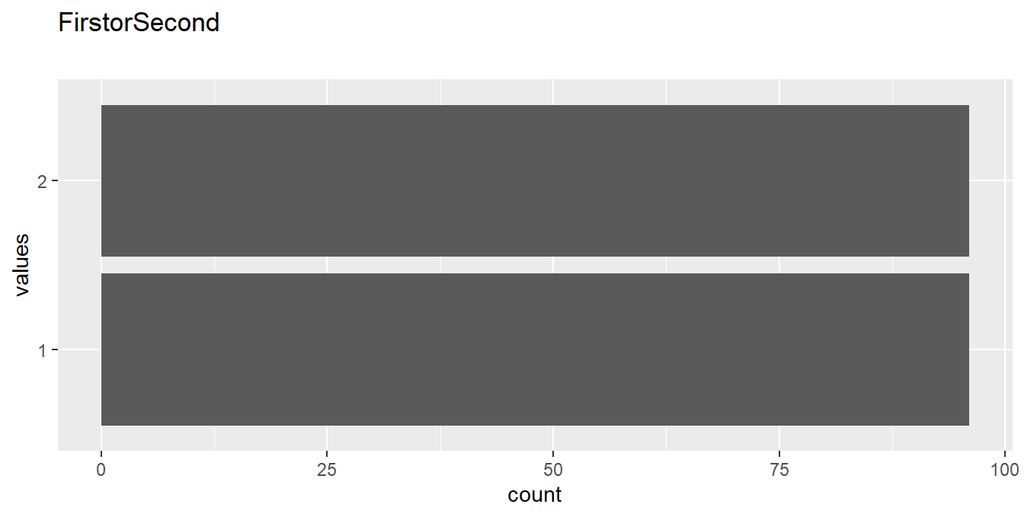

Distribution of values for FirstorSecond

96 missing values.

#### Summary statistics

| name | data_type | ordered | value_labels | n_missing | complete_rate | n_unique | top_counts | label |
| --- | --- | --- | --- | --- | --- | --- | --- | --- |
| FirstorSecond | factor | FALSE | 1. 1, 2. 2 | 96 | 0.6666667 | 2 | 1: 96, 2: 96 | NA |

### Accuracy

#### Distribution

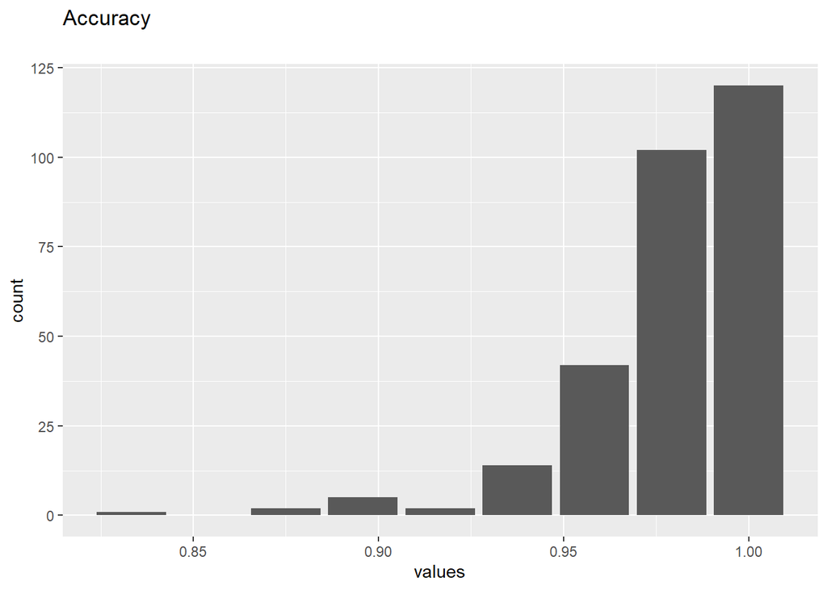

Distribution of values for Accuracy

0 missing values.

#### Summary statistics

| name | data_type | n_missing | complete_rate | min | median | max | mean | sd | hist | label |
| --- | --- | --- | --- | --- | --- | --- | --- | --- | --- | --- |
| Accuracy | numeric | 0 | 1 | 0.83 | 0.98 | 1 | 0.979673 | 0.0250468 | ▁▁▁▂▇ | NA |

### SentenceBlankPictureGrayACC

#### Distribution

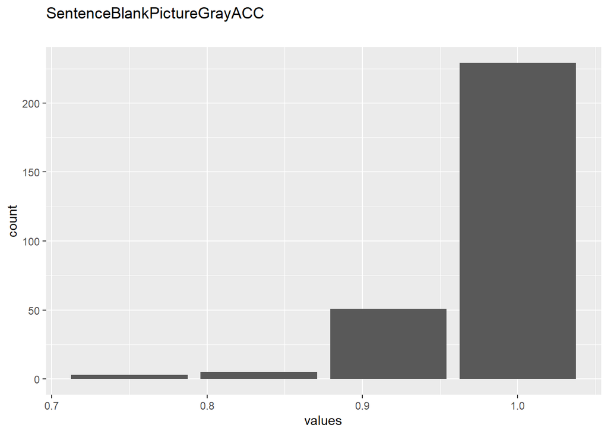

Distribution of values for SentenceBlankPictureGrayACC

0 missing values.

#### Summary statistics

| name | data_type | n_missing | complete_rate | min | median | max | mean | sd | hist | label |
| --- | --- | --- | --- | --- | --- | --- | --- | --- | --- | --- |
| SentenceBlankPictureGrayACC | numeric | 0 | 1 | 0.75 | 1 | 1 | 0.9797454 | 0.0442673 | ▁▁▁▂▇ | NA |

### SentenceBlankPictureColorACC

#### Distribution

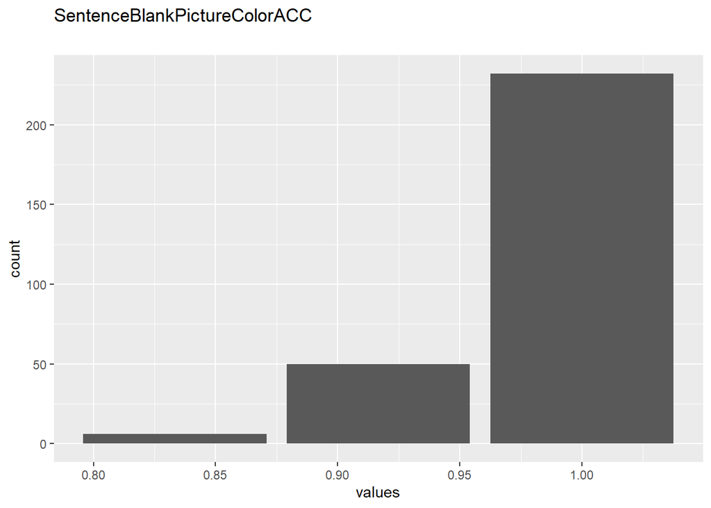

Distribution of values for SentenceBlankPictureColorACC

0 missing values.

#### Summary statistics

| name | data_type | n_missing | complete_rate | min | median | max | mean | sd | hist | label |
| --- | --- | --- | --- | --- | --- | --- | --- | --- | --- | --- |
| SentenceBlankPictureColorACC | numeric | 0 | 1 | 0.83 | 1 | 1 | 0.9820602 | 0.0383092 | ▁▁▂▁▇ | NA |

### SentenceColorPictureColorACC

#### Distribution

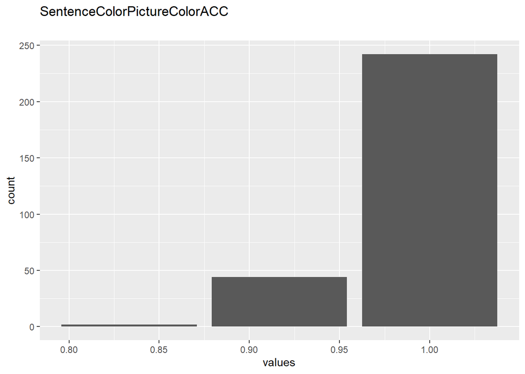

Distribution of values for SentenceColorPictureColorACC

0 missing values.

#### Summary statistics

| name | data_type | n_missing | complete_rate | min | median | max | mean | sd | hist | label |
| --- | --- | --- | --- | --- | --- | --- | --- | --- | --- | --- |
| SentenceColorPictureColorACC | numeric | 0 | 1 | 0.83 | 1 | 1 | 0.9861111 | 0.032629 | ▁▁▂▁▇ | NA |

### SentenceColorPictureGrayscaleACC

#### Distribution

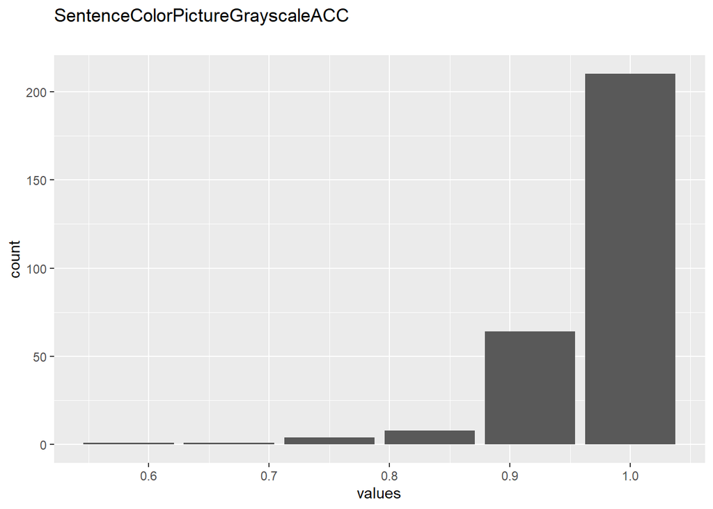

Distribution of values for SentenceColorPictureGrayscaleACC

0 missing values.

#### Summary statistics

| name | data_type | n_missing | complete_rate | min | median | max | mean | sd | hist | label |
| --- | --- | --- | --- | --- | --- | --- | --- | --- | --- | --- |
| SentenceColorPictureGrayscaleACC | numeric | 0 | 1 | 0.58 | 1 | 1 | 0.9707755 | 0.0576973 | ▁▁▁▁▇ | NA |

### SentenceBlankPictureGrayRT

#### Distribution

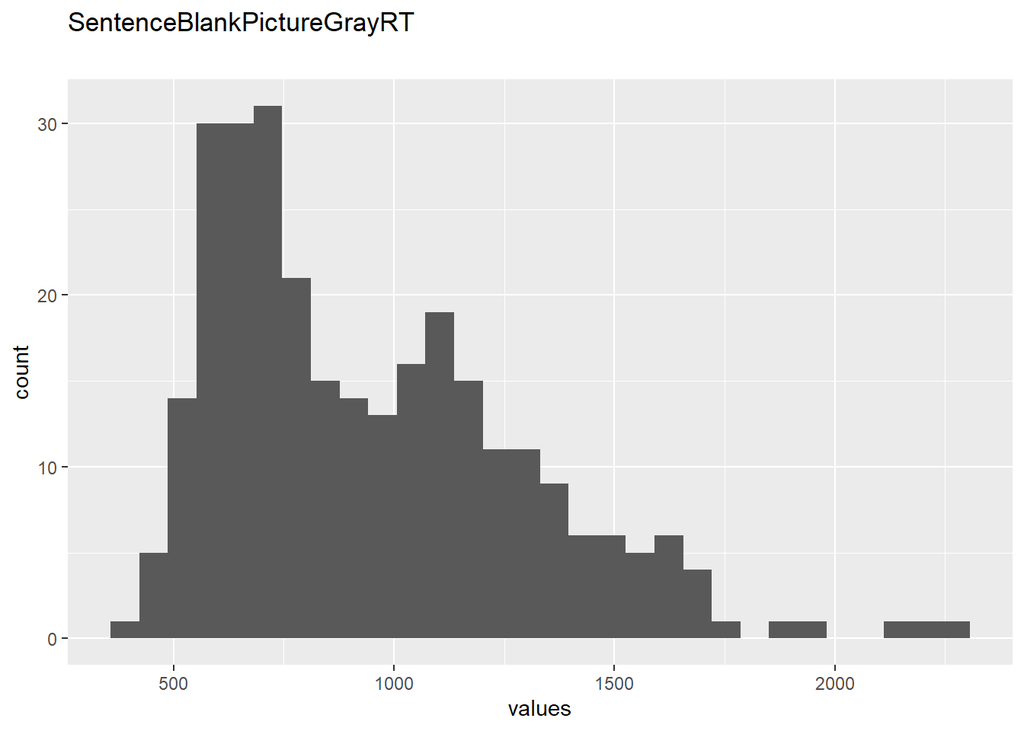

Distribution of values for SentenceBlankPictureGrayRT

0 missing values.

#### Summary statistics

| name | data_type | n_missing | complete_rate | min | median | max | mean | sd | hist | label |
| --- | --- | --- | --- | --- | --- | --- | --- | --- | --- | --- |
| SentenceBlankPictureGrayRT | numeric | 0 | 1 | 368 | 866 | 2251 | 945.9705 | 352.1593 | ▇▇▅▁▁ | NA |

### SentenceBlankPictureColorRT

#### Distribution

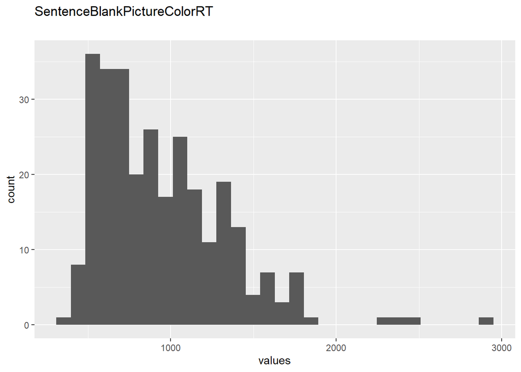

Distribution of values for SentenceBlankPictureColorRT

0 missing values.

#### Summary statistics

| name | data_type | n_missing | complete_rate | min | median | max | mean | sd | hist | label |
| --- | --- | --- | --- | --- | --- | --- | --- | --- | --- | --- |
| SentenceBlankPictureColorRT | numeric | 0 | 1 | 359 | 868 | 2912 | 947.6806 | 388.9104 | ▇▆▂▁▁ | NA |

### SentenceColorPictureColorRT

#### Distribution

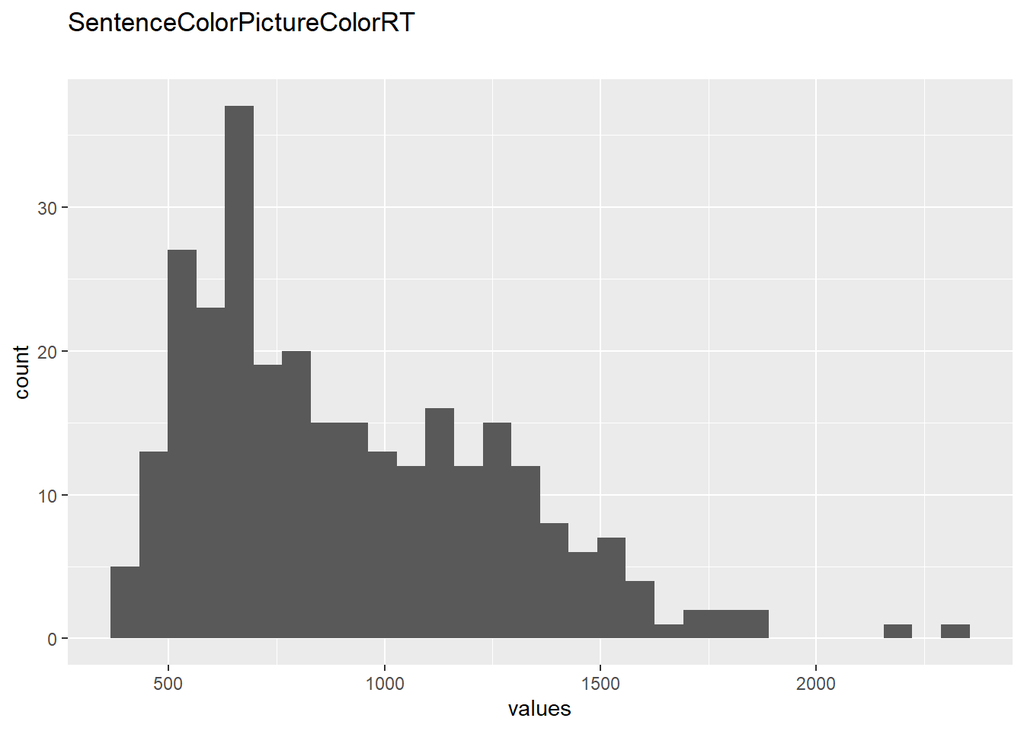

Distribution of values for SentenceColorPictureColorRT

0 missing values.

#### Summary statistics

| name | data_type | n_missing | complete_rate | min | median | max | mean | sd | hist | label |
| --- | --- | --- | --- | --- | --- | --- | --- | --- | --- | --- |
| SentenceColorPictureColorRT | numeric | 0 | 1 | 376 | 829 | 2300 | 916.592 | 354.7749 | ▇▆▃▁▁ | NA |

### SentenceColorPictureGrayRT

#### Distribution

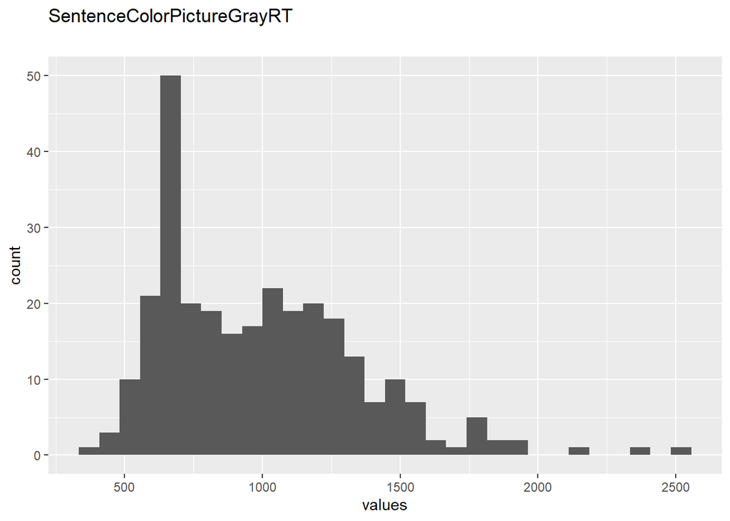

Distribution of values for SentenceColorPictureGrayRT

0 missing values.

#### Summary statistics

| name | data_type | n_missing | complete_rate | min | median | max | mean | sd | hist | label |
| --- | --- | --- | --- | --- | --- | --- | --- | --- | --- | --- |
| SentenceColorPictureGrayRT | numeric | 0 | 1 | 392 | 951 | 2540 | 990.7812 | 360.6907 | ▇▇▃▁▁ | NA |

### Experiment

#### Distribution

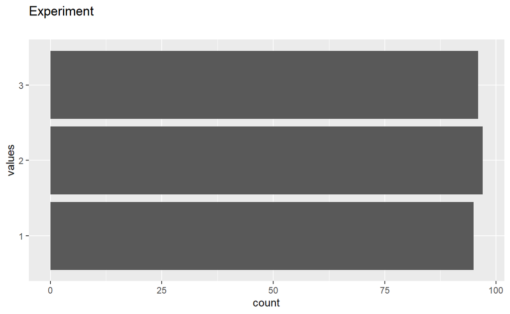

Distribution of values for Experiment

0 missing values.

#### Summary statistics

| name | data_type | ordered | value_labels | n_missing | complete_rate | n_unique | top_counts | label |
| --- | --- | --- | --- | --- | --- | --- | --- | --- |
| Experiment | factor | FALSE | 1. 1, 2. 2, 3. 3 | 0 | 1 | 3 | 2: 97, 3: 96, 1: 95 | NA |

## Missingness report

| description | FirstorSecond | var_miss | n_miss |
| --- | --- | --- | --- |
| Missing values in 0 variables | 1 | 0 | 192 |
| Missing values in 1 variables | 0 | 1 | 96 |
| Missing values per variable | 96 | 96 | 96 |